# Bray-Curtis PERMANOVA of longitudinal full-length 16S profiles

This analysis quantifies temporal differences in species-level full-length 16S community composition using Bray-Curtis PERMANOVA. It reports baseline-versus- time-point contrasts, a global main model, clinical and antibiotic sensitivity models, and a summary of temporal-effect robustness across model specifications.

```r
required_packages <- c(
  "vegan", "dplyr", "tidyr", "tibble", "purrr", "ggplot2"
)
missing_packages <- required_packages[
  !vapply(required_packages, requireNamespace, logical(1), quietly = TRUE)
]
if (length(missing_packages) > 0L) {
  stop(
    "Install the following R packages before running this analysis: ",
    paste(missing_packages, collapse = ", ")
  )
}

suppressPackageStartupMessages({
  library(vegan)
  library(dplyr)
  library(tidyr)
  library(tibble)
  library(purrr)
  library(ggplot2)
})

input_file <- "000.input16S.Rds"
analysis_name <- "03.16sPCoA.PERMANOVA"
output_root <- analysis_name
adonis_dir <- file.path(output_root, "adonis2")
figure_dir <- file.path(output_root, "figures")

dir.create(output_root, recursive = TRUE, showWarnings = FALSE)
dir.create(adonis_dir, recursive = TRUE, showWarnings = FALSE)
dir.create(figure_dir, recursive = TRUE, showWarnings = FALSE)

knitr::opts_chunk$set(
  fig.path = file.path(output_root, "knitr_figures", "")
)

# These analysis parameters are unchanged from the source Rmd.
key_groups <- c("BL", "D0", "D14", "M1", "M2", "M3", "M6")
baseline_group <- "BL"
n_permutations <- 9999
min_paired_cycles <- 3
min_pairwise_samples <- 3
min_factor_levels <- 2
min_category_n <- 3

set.seed(20260528)
```

# 1 1. Utility functions

```r
write_result_csv <- function(data, filename) {
  utils::write.csv(
    data,
    file.path(adonis_dir, filename),
    row.names = FALSE,
    na = ""
  )
}

factor_usable <- function(x, min_n = 1L) {
  x <- droplevels(factor(x))
  nlevels(x) >= min_factor_levels && all(table(x) >= min_n)
}

numeric_usable <- function(x) {
  x <- as.numeric(x)
  sum(!is.na(x)) >= 3L && stats::sd(x, na.rm = TRUE) > 0
}

is_variable_usable <- function(data, variable, min_n = 1L) {
  if (!variable %in% names(data)) return(FALSE)
  x <- data[[variable]]
  if (is.numeric(x)) numeric_usable(x) else factor_usable(x, min_n)
}

is_model_matrix_full_rank <- function(data, terms) {
  rhs <- paste(terms, collapse = " + ")
  model_matrix <- tryCatch(
    stats::model.matrix(
      stats::as.formula(paste("~", rhs)),
      data = data
    ),
    error = function(e) NULL
  )
  !is.null(model_matrix) && qr(model_matrix)$rank == ncol(model_matrix)
}

extract_adonis_table <- function(fit, model_name) {
  as.data.frame(fit) |>
    tibble::rownames_to_column("term") |>
    tibble::as_tibble() |>
    dplyr::rename(
      Df = dplyr::any_of("Df"),
      SumOfSqs = dplyr::any_of("SumOfSqs"),
      R2 = dplyr::any_of("R2"),
      F = dplyr::any_of("F"),
      P = dplyr::any_of("Pr(>F)")
    ) |>
    dplyr::mutate(model = model_name) |>
    dplyr::relocate(.data$model, .data$term)
}

run_adonis2_model <- function(
    distance,
    metadata,
    terms,
    model_name,
    permutations = n_permutations,
    strata = NULL) {

  metadata <- as.data.frame(metadata)
  rownames(metadata) <- metadata$sample_id

  missing_terms <- setdiff(terms, names(metadata))
  if (length(missing_terms) > 0L) {
    return(tibble::tibble(
      model = model_name,
      term = NA_character_,
      status = "skipped",
      reason = paste("missing terms:", paste(missing_terms, collapse = ", "))
    ))
  }

  keep <- stats::complete.cases(metadata[, terms, drop = FALSE])
  metadata_use <- droplevels(metadata[keep, , drop = FALSE])
  distance_matrix <- as.matrix(distance)
  distance_use <- stats::as.dist(
    distance_matrix[
      rownames(metadata_use),
      rownames(metadata_use),
      drop = FALSE
    ]
  )

  if (nrow(metadata_use) < min_pairwise_samples) {
    return(tibble::tibble(
      model = model_name,
      term = NA_character_,
      status = "skipped",
      reason = paste("too few samples:", nrow(metadata_use))
    ))
  }
  if (!is_model_matrix_full_rank(metadata_use, terms)) {
    return(tibble::tibble(
      model = model_name,
      term = NA_character_,
      status = "skipped",
      reason = "model matrix is rank deficient / collinear"
    ))
  }

  distance_for_model <- distance_use
  model_formula <- stats::as.formula(
    paste("distance_for_model ~", paste(terms, collapse = " + "))
  )
  environment(model_formula) <- environment()

  fit <- tryCatch(
    {
      if (is.null(strata)) {
        vegan::adonis2(
          model_formula,
          data = metadata_use,
          permutations = permutations,
          by = "margin"
        )
      } else {
        vegan::adonis2(
          model_formula,
          data = metadata_use,
          permutations = permutations,
          by = "margin",
          strata = strata[keep]
        )
      }
    },
    error = function(e) e
  )

  if (inherits(fit, "error")) {
    return(tibble::tibble(
      model = model_name,
      term = NA_character_,
      status = "failed",
      reason = fit$message
    ))
  }

  extract_adonis_table(fit, model_name) |>
    dplyr::mutate(
      status = "ok",
      reason = NA_character_,
      n_samples = nrow(metadata_use)
    )
}

group_effect_row <- function(result_table, model_name) {
  result_table |>
    dplyr::filter(
      .data$model == model_name,
      .data$term == "group_label",
      .data$status == "ok"
    ) |>
    dplyr::slice(1L)
}

format_p_label <- function(p) {
  ifelse(
    is.na(p),
    "P = NA",
    ifelse(p < 0.001, "P < 0.001", paste0("P = ", sprintf("%.4f", p)))
  )
}
```

# 2 2. Prepare de-identified metadata and Bray-Curtis distances

Only fields used by the requested models are retained. The released `Sample_Name` replaces the original sample identifier.

```r
if (!file.exists(input_file)) {
  stop("Input file not found: ", input_file)
}

input16S <- readRDS(input_file)
if (!is.list(input16S) || !all(c("dat_rela", "metainfo") %in% names(input16S))) {
  stop("000.input16S.Rds must contain dat_rela and metainfo.")
}

dat_rela <- input16S$dat_rela
metainfo <- input16S$metainfo

required_metadata <- c(
  "Sample_Name", "Patient_ID", "pId_new", "timeIDcontiue", "batch",
  "Age", "Sex", "Disease", "project_id", "abx_recent", "abx_days_14",
  "broad_abx_14d"
)
missing_metadata <- setdiff(required_metadata, names(metainfo))
if (length(missing_metadata) > 0L) {
  stop("metainfo is missing required column(s): ", paste(missing_metadata, collapse = ", "))
}
if (!identical(colnames(dat_rela), as.character(metainfo$Sample_Name))) {
  stop("dat_rela columns are not aligned with metainfo$Sample_Name.")
}

group_label_all <- sub("^[0-9]+_", "", metainfo$timeIDcontiue)

meta_6tp <- metainfo |>
  dplyr::transmute(
    sample_id = as.character(.data$Sample_Name),
    pId = factor(.data$Patient_ID),
    pId_new = factor(.data$pId_new),
    group_label = factor(group_label_all, levels = key_groups),
    batch = factor(.data$batch),
    Age_years = as.numeric(.data$Age),
    Sex = factor(.data$Sex),
    Disease = factor(.data$Disease),
    project_id = factor(.data$project_id),
    abx_recent = factor(.data$abx_recent),
    abx_days_14 = as.numeric(.data$abx_days_14),
    broad_abx_14d = factor(.data$broad_abx_14d)
  ) |>
  dplyr::filter(!is.na(.data$group_label)) |>
  droplevels()

meta_6tp$Age_scaled <- as.numeric(scale(meta_6tp$Age_years))

if (anyNA(meta_6tp$abx_days_14)) {
  stop("abx_days_14 must be numeric and non-missing.")
}

abundance_taxa_by_sample <- as.matrix(
  dat_rela[, meta_6tp$sample_id, drop = FALSE]
)
storage.mode(abundance_taxa_by_sample) <- "numeric"
abundance_taxa_by_sample[is.na(abundance_taxa_by_sample)] <- 0

# Convert taxa x samples to samples x taxa and remove empty taxa/samples.
abundance_matrix <- t(abundance_taxa_by_sample)
abundance_matrix <- abundance_matrix[
  rowSums(abundance_matrix) > 0,
  colSums(abundance_matrix) > 0,
  drop = FALSE
]

# Preserve the source script's automatic relative-abundance check.
sample_sums <- rowSums(abundance_matrix)
already_relative <- all(sample_sums > 0) &&
  stats::median(abs(sample_sums - 1), na.rm = TRUE) < 1e-3
if (!already_relative) {
  abundance_matrix <- sweep(abundance_matrix, 1, rowSums(abundance_matrix), "/")
  abundance_matrix[is.na(abundance_matrix)] <- 0
}

meta_6tp <- meta_6tp |>
  dplyr::filter(.data$sample_id %in% rownames(abundance_matrix)) |>
  dplyr::arrange(match(.data$sample_id, rownames(abundance_matrix))) |>
  droplevels()
abundance_matrix <- abundance_matrix[meta_6tp$sample_id, , drop = FALSE]

stopifnot(identical(meta_6tp$sample_id, rownames(abundance_matrix)))

bray_distance <- vegan::vegdist(abundance_matrix, method = "bray")
bray_matrix <- as.matrix(bray_distance)

data.frame(
  time_group = key_groups,
  n_samples = as.integer(table(meta_6tp$group_label))
)
```

```
##   time_group n_samples
## 1         BL        28
## 2         D0        19
## 3        D14        26
## 4         M1        32
## 5         M2        22
## 6         M3        24
## 7         M6        12
```

# 3 3. Global main PERMANOVA

```r
global_main <- run_adonis2_model(
  distance = bray_distance,
  metadata = meta_6tp,
  terms = c("batch", "Age_scaled", "group_label"),
  model_name = "Global_main_batch_age_group"
)

write_result_csv(global_main, "global_PERMANOVA_main.csv")
global_main
```

```
## # A tibble: 5 × 10
##   model        term     Df SumOfSqs     R2     F       P status reason n_samples
##   <chr>        <chr> <dbl>    <dbl>  <dbl> <dbl>   <dbl> <chr>  <chr>      <int>
## 1 Global_main… batch     1     1.35 0.0231  3.90  0.0001 ok     <NA>         163
## 2 Global_main… Age_…     1     1.05 0.0180  3.05  0.0001 ok     <NA>         163
## 3 Global_main… grou…     6     2.71 0.0464  1.31  0.0168 ok     <NA>         163
## 4 Global_main… Resi…   154    53.2  0.911  NA    NA      ok     <NA>         163
## 5 Global_main… Total   162    58.4  1      NA    NA      ok     <NA>         163
```

# 4 4. Antibiotic sensitivity models

Each antibiotic variable is entered in a separate model, as in the source analysis, to avoid combining correlated exposure variables.

```r
antibiotic_models <- list(
  Model_abx_recent = c("batch", "Age_scaled", "abx_recent", "group_label"),
  Model_abx_days_14 = c("batch", "Age_scaled", "abx_days_14", "group_label"),
  Model_broad_abx_14d = c("batch", "Age_scaled", "broad_abx_14d", "group_label")
)

antibiotic_results <- purrr::imap_dfr(
  antibiotic_models,
  ~ run_adonis2_model(
    bray_distance,
    meta_6tp,
    terms = .x,
    model_name = .y
  )
)

write_result_csv(
  antibiotic_results,
  "antibiotic_sensitivity_PERMANOVA_all.csv"
)

antibiotic_results |>
  dplyr::filter(.data$term == "group_label")
```

```
## # A tibble: 3 × 10
##   model         term     Df SumOfSqs     R2     F      P status reason n_samples
##   <chr>         <chr> <dbl>    <dbl>  <dbl> <dbl>  <dbl> <chr>  <chr>      <int>
## 1 Model_abx_re… grou…     6     2.56 0.0438  1.25 0.038  ok     <NA>         163
## 2 Model_abx_da… grou…     6     2.49 0.0427  1.21 0.0591 ok     <NA>         163
## 3 Model_broad_… grou…     6     2.28 0.0390  1.11 0.193  ok     <NA>         163
```

# 5 5. Clinical sensitivity models

```r
if (!is_variable_usable(meta_6tp, "Sex", min_n = min_category_n)) {
  stop("Sex has fewer than two usable levels or a category is too small.")
}
if (!is_variable_usable(meta_6tp, "Disease", min_n = min_category_n)) {
  stop("Disease has fewer than two usable levels or a category is too small.")
}

clinical_results <- dplyr::bind_rows(
  run_adonis2_model(
    bray_distance,
    meta_6tp,
    terms = c("batch", "Age_scaled", "Sex", "group_label"),
    model_name = "Clinical_model_1_batch_age_sex_group"
  ),
  run_adonis2_model(
    bray_distance,
    meta_6tp,
    terms = c("batch", "Age_scaled", "Sex", "Disease", "group_label"),
    model_name = "Clinical_model_2_batch_age_sex_disease_group"
  )
)

write_result_csv(
  clinical_results,
  "clinical_sensitivity_PERMANOVA_all.csv"
)

clinical_results |>
  dplyr::filter(.data$term == "group_label")
```

```
## # A tibble: 2 × 10
##   model         term     Df SumOfSqs     R2     F      P status reason n_samples
##   <chr>         <chr> <dbl>    <dbl>  <dbl> <dbl>  <dbl> <chr>  <chr>      <int>
## 1 Clinical_mod… grou…     6     2.68 0.0459  1.31 0.0168 ok     <NA>         163
## 2 Clinical_mod… grou…     6     2.61 0.0446  1.35 0.0084 ok     <NA>         163
```

# 6 6. Pairwise PERMANOVA: baseline versus each timepoint

When at least three treatment cycles contain both baseline and the target timepoint, only those paired cycles are used and permutations are restricted by `pId_new`.

```r
run_pairwise_main <- function(target_group) {
  metadata_pair_all <- meta_6tp |>
    dplyr::filter(.data$group_label %in% c(baseline_group, target_group)) |>
    droplevels()

  cycles_with_both <- metadata_pair_all |>
    dplyr::count(.data$pId_new, .data$group_label) |>
    dplyr::count(.data$pId_new) |>
    dplyr::filter(.data$n == 2L) |>
    dplyr::pull(.data$pId_new)

  paired_only_used <- length(cycles_with_both) >= min_paired_cycles
  metadata_pair <- if (paired_only_used) {
    metadata_pair_all |>
      dplyr::filter(.data$pId_new %in% cycles_with_both) |>
      droplevels()
  } else {
    metadata_pair_all
  }

  comparison <- paste(target_group, "vs", baseline_group)
  if (
    nrow(metadata_pair) < min_pairwise_samples ||
      nlevels(metadata_pair$group_label) < 2L
  ) {
    return(tibble::tibble(
      comparison = comparison,
      n_samples = nrow(metadata_pair),
      n_cycles = dplyr::n_distinct(metadata_pair$pId_new),
      paired_only_used = paired_only_used,
      strata_used = FALSE,
      R2 = NA_real_,
      F = NA_real_,
      P = NA_real_,
      status = "skipped",
      reason = "too few samples or only one group"
    ))
  }

  sample_ids <- metadata_pair$sample_id
  distance_pair <- stats::as.dist(
    bray_matrix[sample_ids, sample_ids, drop = FALSE]
  )
  metadata_pair <- as.data.frame(metadata_pair)
  rownames(metadata_pair) <- metadata_pair$sample_id

  run_pairwise_fit <- function(use_strata) {
    distance_for_model <- distance_pair
    model_formula <- distance_for_model ~ group_label

    tryCatch(
      {
        if (use_strata) {
          vegan::adonis2(
            model_formula,
            data = metadata_pair,
            permutations = n_permutations,
            by = "margin",
            strata = metadata_pair$pId_new
          )
        } else {
          vegan::adonis2(
            model_formula,
            data = metadata_pair,
            permutations = n_permutations,
            by = "margin"
          )
        }
      },
      error = function(e) e
    )
  }

  fit <- run_pairwise_fit(paired_only_used)
  strata_used <- paired_only_used && !inherits(fit, "error")
  if (inherits(fit, "error") && paired_only_used) {
    fit <- run_pairwise_fit(FALSE)
    strata_used <- FALSE
  }

  if (inherits(fit, "error")) {
    return(tibble::tibble(
      comparison = comparison,
      n_samples = nrow(metadata_pair),
      n_cycles = dplyr::n_distinct(metadata_pair$pId_new),
      paired_only_used = paired_only_used,
      strata_used = strata_used,
      R2 = NA_real_,
      F = NA_real_,
      P = NA_real_,
      status = "failed",
      reason = fit$message
    ))
  }

  group_row <- extract_adonis_table(fit, "pairwise_main") |>
    dplyr::filter(.data$term == "group_label") |>
    dplyr::slice(1L)

  tibble::tibble(
    comparison = comparison,
    n_samples = nrow(metadata_pair),
    n_cycles = dplyr::n_distinct(metadata_pair$pId_new),
    paired_only_used = paired_only_used,
    strata_used = strata_used,
    R2 = group_row$R2,
    F = group_row$F,
    P = group_row$P,
    status = "ok",
    reason = NA_character_
  )
}

pairwise_results <- purrr::map_dfr(
  setdiff(key_groups, baseline_group),
  run_pairwise_main
) |>
  dplyr::mutate(FDR = stats::p.adjust(.data$P, method = "fdr"))

write_result_csv(
  pairwise_results,
  "pairwise_PERMANOVA_BL_vs_each_timepoint.csv"
)

pairwise_results
```

```
## # A tibble: 6 × 11
##   comparison n_samples n_cycles paired_only_used strata_used     R2     F      P
##   <chr>          <int>    <int> <lgl>            <lgl>        <dbl> <dbl>  <dbl>
## 1 D0 vs BL          32       16 TRUE             TRUE        0.0284 0.876 0.0905
## 2 D14 vs BL         45       22 TRUE             TRUE        0.0426 1.92  0.0005
## 3 M1 vs BL          53       26 TRUE             TRUE        0.0237 1.24  0.0399
## 4 M2 vs BL          38       19 TRUE             TRUE        0.0226 0.833 0.183
## 5 M3 vs BL          40       20 TRUE             TRUE        0.0294 1.15  0.0195
## 6 M6 vs BL          16        8 TRUE             TRUE        0.0703 1.06  0.0859
## # ℹ 3 more variables: status <chr>, reason <chr>, FDR <dbl>
```

# 7 7. Verification subset requested for the final report

This verification excludes samples with high-impact broad-spectrum antibiotic exposure, restricts the longitudinal window to BL through M2, and adjusts for batch, age, disease category, sex, and recent antibiotic exposure.

```r
verification_groups <- c("BL", "D0", "D14", "M1", "M2")

verification_meta <- meta_6tp |>
  dplyr::filter(
    as.character(.data$broad_abx_14d) == "No",
    as.character(.data$group_label) %in% verification_groups
  ) |>
  dplyr::mutate(
    group_label = factor(as.character(.data$group_label), levels = verification_groups)
  ) |>
  droplevels()

verification_ids <- verification_meta$sample_id
verification_distance <- stats::as.dist(
  bray_matrix[verification_ids, verification_ids, drop = FALSE]
)

verification_model_name <- paste0(
  "Verification_exclude_broad_abx_BL_to_M2_",
  "batch_age_disease_sex_recent_abx_group"
)

verification_result <- run_adonis2_model(
  verification_distance,
  verification_meta,
  terms = c(
    "batch", "Age_scaled", "Disease", "Sex", "abx_recent", "group_label"
  ),
  model_name = verification_model_name
)

write_result_csv(
  verification_result,
  "verification_subset_PERMANOVA.csv"
)

verification_group_effect <- group_effect_row(
  verification_result,
  verification_model_name
)
if (nrow(verification_group_effect) != 1L) {
  stop("The verification model did not return a valid group_label effect.")
}

verification_summary <- tibble::tibble(
  analysis = "Exclude broad-spectrum antibiotic exposure; BL-M2 subset",
  adjusted_for = "batch, age, disease category, sex, recent antibiotic exposure",
  n_samples = verification_group_effect$n_samples,
  R2 = verification_group_effect$R2,
  R2_percent = 100 * verification_group_effect$R2,
  P = verification_group_effect$P
)

write_result_csv(
  verification_summary,
  "verification_subset_time_group_effect.csv"
)

cat(
  sprintf(
    "Time-group effect: R2 = %.2f%%, %s",
    verification_summary$R2_percent,
    format_p_label(verification_summary$P)
  )
)
```

```
## Time-group effect: R2 = 5.13%, P = 0.0223
```

# 8 8. Forest plot of adjusted time-group effects

The plot uses the `group_label` row from each fitted model. R2 is displayed as percent explained variance, and the dashed vertical reference is the observed main-model R2 rather than a manually entered approximation.

```r
main_effect <- group_effect_row(
  global_main,
  "Global_main_batch_age_group"
)
clinical_sex_effect <- group_effect_row(
  clinical_results,
  "Clinical_model_1_batch_age_sex_group"
)
clinical_disease_effect <- group_effect_row(
  clinical_results,
  "Clinical_model_2_batch_age_sex_disease_group"
)
recent_abx_effect <- group_effect_row(
  antibiotic_results,
  "Model_abx_recent"
)
days_abx_effect <- group_effect_row(
  antibiotic_results,
  "Model_abx_days_14"
)
broad_abx_effect <- group_effect_row(
  antibiotic_results,
  "Model_broad_abx_14d"
)

model_data <- tibble::tibble(
  Model_Type = c(
    "Main Model",
    "Clinical Sensitivity", "Clinical Sensitivity",
    "Antibiotic Sensitivity", "Antibiotic Sensitivity", "Antibiotic Sensitivity",
    "Verification Model"
  ),
  Model_Name = c(
    "Main (Batch + Age + Group)",
    "Main + Sex",
    "Main + Sex + Disease",
    "Main + Recent Abx",
    "Main + 14d Abx",
    "Main + 14d Broad Abx (High-impact)",
    "Exclude Broad Abx; BL-M2; Full Adjustment"
  ),
  R2 = 100 * c(
    main_effect$R2,
    clinical_sex_effect$R2,
    clinical_disease_effect$R2,
    recent_abx_effect$R2,
    days_abx_effect$R2,
    broad_abx_effect$R2,
    verification_group_effect$R2
  ),
  P_value = c(
    main_effect$P,
    clinical_sex_effect$P,
    clinical_disease_effect$P,
    recent_abx_effect$P,
    days_abx_effect$P,
    broad_abx_effect$P,
    verification_group_effect$P
  )
)

model_data$Model_Name <- factor(
  model_data$Model_Name,
  levels = rev(model_data$Model_Name)
)
model_data$Model_Type <- factor(
  model_data$Model_Type,
  levels = c(
    "Main Model", "Clinical Sensitivity", "Antibiotic Sensitivity",
    "Verification Model"
  )
)
model_data <- model_data |>
  dplyr::mutate(
    Significance = ifelse(
      .data$P_value < 0.05,
      "Significant",
      "Not Significant"
    ),
    Label = format_p_label(.data$P_value)
  )

write_result_csv(
  model_data |>
    dplyr::mutate(
      Model_Name = as.character(.data$Model_Name),
      Model_Type = as.character(.data$Model_Type)
    ),
  "permanova_temporal_effect_robustness.csv"
)

model_data
```

```
## # A tibble: 7 × 6
##   Model_Type             Model_Name                R2 P_value Significance Label
##   <fct>                  <fct>                  <dbl>   <dbl> <chr>        <chr>
## 1 Main Model             Main (Batch + Age + G…  4.64  0.0168 Significant  P = …
## 2 Clinical Sensitivity   Main + Sex              4.59  0.0168 Significant  P = …
## 3 Clinical Sensitivity   Main + Sex + Disease    4.46  0.0084 Significant  P = …
## 4 Antibiotic Sensitivity Main + Recent Abx       4.38  0.038  Significant  P = …
## 5 Antibiotic Sensitivity Main + 14d Abx          4.27  0.0591 Not Signifi… P = …
## 6 Antibiotic Sensitivity Main + 14d Broad Abx …  3.90  0.193  Not Signifi… P = …
## 7 Verification Model     Exclude Broad Abx; BL…  5.13  0.0223 Significant  P = …
```

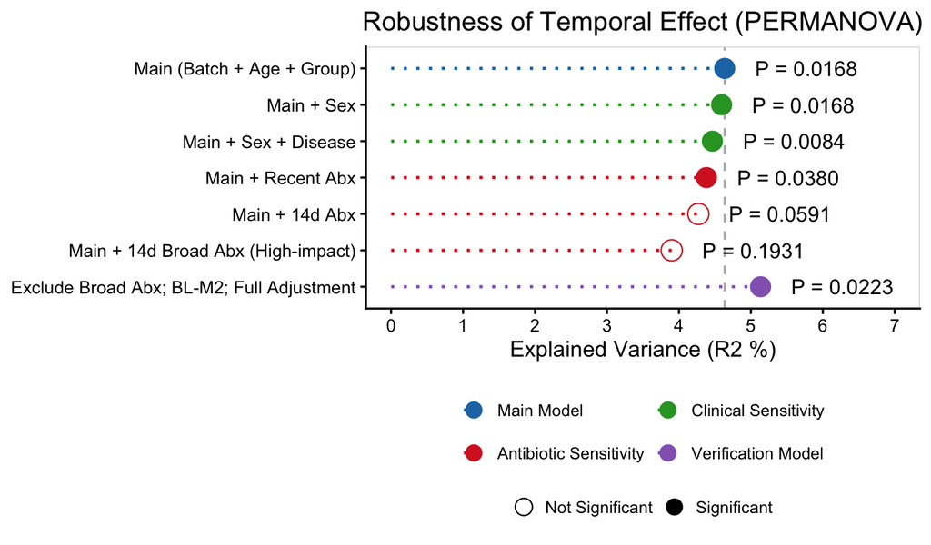

```r
main_r2_percent <- main_effect$R2 * 100
x_axis_max <- max(6, ceiling(max(model_data$R2, na.rm = TRUE) + 1))

p_forest <- ggplot2::ggplot(
  model_data,
  ggplot2::aes(x = .data$R2, y = .data$Model_Name)
) +
  ggplot2::geom_vline(
    xintercept = main_r2_percent,
    linetype = "dashed",
    color = "grey70"
  ) +
  ggplot2::geom_point(
    ggplot2::aes(
      color = .data$Model_Type,
      shape = .data$Significance
    ),
    size = 5
  ) +
  ggplot2::geom_segment(
    ggplot2::aes(
      x = 0,
      xend = .data$R2,
      y = .data$Model_Name,
      yend = .data$Model_Name,
      color = .data$Model_Type
    ),
    linetype = "dotted",
    linewidth = 0.8
  ) +
  ggplot2::geom_text(
    ggplot2::aes(label = .data$Label),
    hjust = -0.3,
    size = 4,
    family = "ArialMT"
  ) +
  ggplot2::scale_x_continuous(
    limits = c(0, x_axis_max),
    breaks = seq(0, x_axis_max, 1)
  ) +
  ggplot2::scale_color_manual(
    values = c(
      "Main Model" = "#1F77B4",
      "Clinical Sensitivity" = "#2CA02C",
      "Antibiotic Sensitivity" = "#D62728",
      "Verification Model" = "#9467BD"
    )
  ) +
  ggplot2::scale_shape_manual(
    values = c(
      "Significant" = 16,
      "Not Significant" = 1
    )
  ) +
  ggplot2::guides(
    color = ggplot2::guide_legend(
      order = 1,
      nrow = 2,
      byrow = TRUE,
      override.aes = list(shape = 16, size = 4)
    ),
    shape = ggplot2::guide_legend(
      order = 2,
      nrow = 1,
      byrow = TRUE,
      override.aes = list(color = "black", size = 4)
    )
  ) +
  ggplot2::labs(
    x = "Explained Variance (R2 %)",
    y = NULL,
    title = "Robustness of Temporal Effect (PERMANOVA)"
  ) +
  ggplot2::theme_classic(base_size = 12) +
  ggplot2::theme(
    legend.position = "bottom",
    legend.box = "vertical",
    legend.box.just = "center",
    legend.title = ggplot2::element_blank(),
    legend.text = ggplot2::element_text(size = 9),
    legend.key.width = grid::unit(0.8, "lines"),
    legend.spacing.y = grid::unit(0, "pt"),
    axis.title.y = ggplot2::element_blank(),
    plot.title = ggplot2::element_text(hjust = 0.5),
    panel.grid = ggplot2::element_blank(),
    panel.border = ggplot2::element_rect(fill = NA, colour = "grey87")
  )

forest_pdf <- file.path(
  figure_dir,
  "permanova_temporal_effect_robustness.pdf"
)

ggplot2::ggsave(
  filename = forest_pdf,
  plot = p_forest,
  width = 7.00,
  height = 4.10,
  device = "pdf"
)

p_forest
```